# Homework Comments

Yuanting Lu

11/19/2020

# Homework 1

## Chapter 1

### #3

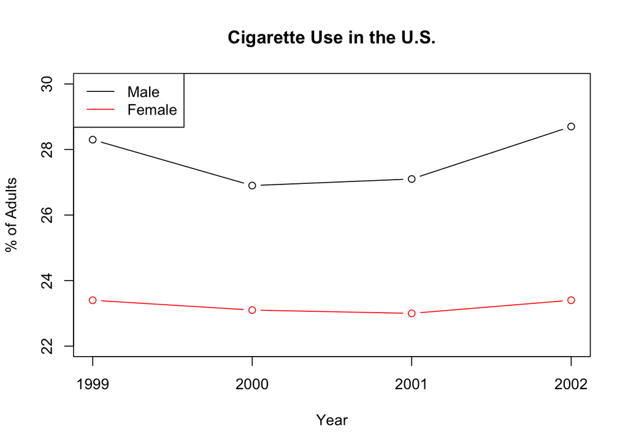

```r
plot(1:4, c(28.3, 26.9, 27.1, 28.7), type = "b",
     xaxt = "n", xlab = "Year",
     ylim = c(22, 30), ylab = "% of Adults",
     main = "Cigarette Use in the U.S.")
lines(1:4, c(23.4, 23.1, 23, 23.4), type = "b", col = "red")
axis(1, at = 1:4, labels = 1999:2002)
legend("topleft",
       legend = c("Male", "Female"),
       lty = c(1, 1),
       col = c("black", "red"))
```

Explanations:

- plot function plots the data for the male group.
  - The first argument is the x-coordinates. `1:4` means 1, 2, 3, 4.
  - The second argument is the y-coordinates.
  - `type = "b"` means plot **b**oth data points and lines.
  - `xaxt = "n"` hides the **x**-**ax**is **t**icks.
  - `xlab` is the **x** **lab**el.
  - `ylim` are the **y** value **lim**its.
  - `ylab` is the **y** **lab**el.
  - `main` is the title of the graph.
- line function adds the data for the female group.
  - `col` is the **col**or of the line.
- axis function writes the labels on the x axis. (Remember we hid the default ticks earlier?)
  - The first argument 1 means bottom axis. (FYI, 2 means left axis.)
  - `at` specifies the ticks **at** where we want to write the labels (i.e., 1, 2, 3 and 4).
  - `labels` adds the labels at the ticks we specified earlier. (i.e., put 1999 at x=1, 2000 at x=2, 2001 at x=3 and 2002 at x=4.)
- legend function adds the legend to the graph.
  - The first argument is the location of the legend, e.g., topleft.
  - `legend` option specifies the words to be displayed as legend.
  - `lty` is the **l**ine **ty**pe. 1 means solid line.

# Homework 2

## Section 2.2

### #1

```r
size <- c(5, 13, 9, 12, 7, 4, 8, 6, 6, 10, 7, 11, 10, 8, 15,
8, 6, 9, 12, 10, 7, 11, 10, 8, 12, 9, 7, 10, 7, 8)
table(size)
```

```
## size
##  4  5  6  7  8  9 10 11 12 13 15
##  1  1  3  5  5  3  5  2  3  1  1
```

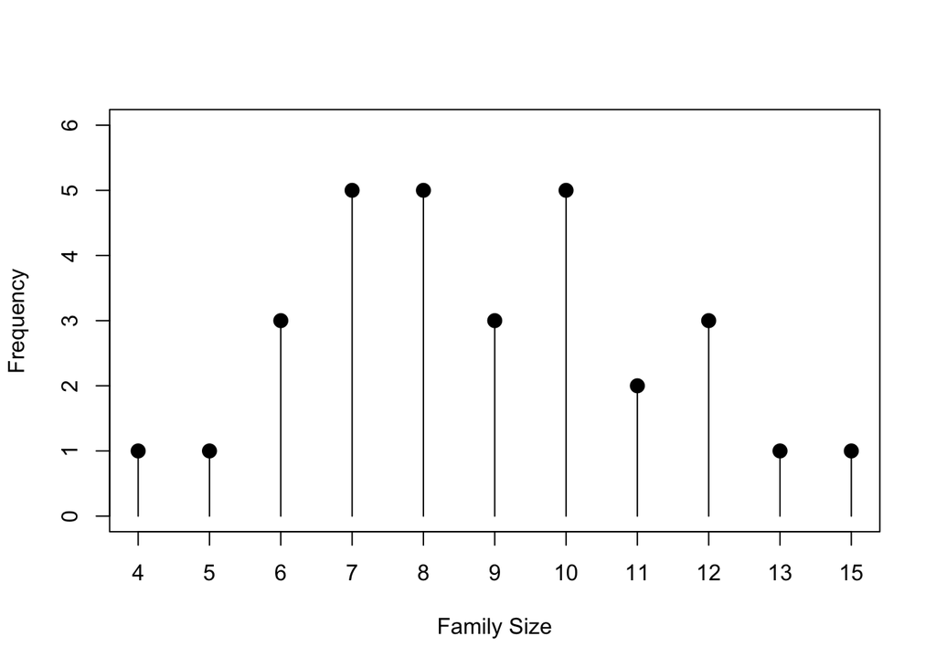

```r
source("https://albums.yuanting.lu/sta126/nicer.R")
lollipop(table(size),
         breaks = 3.5:15.5,
         ylim = c(0, 6), xlab = "Family Size")
```

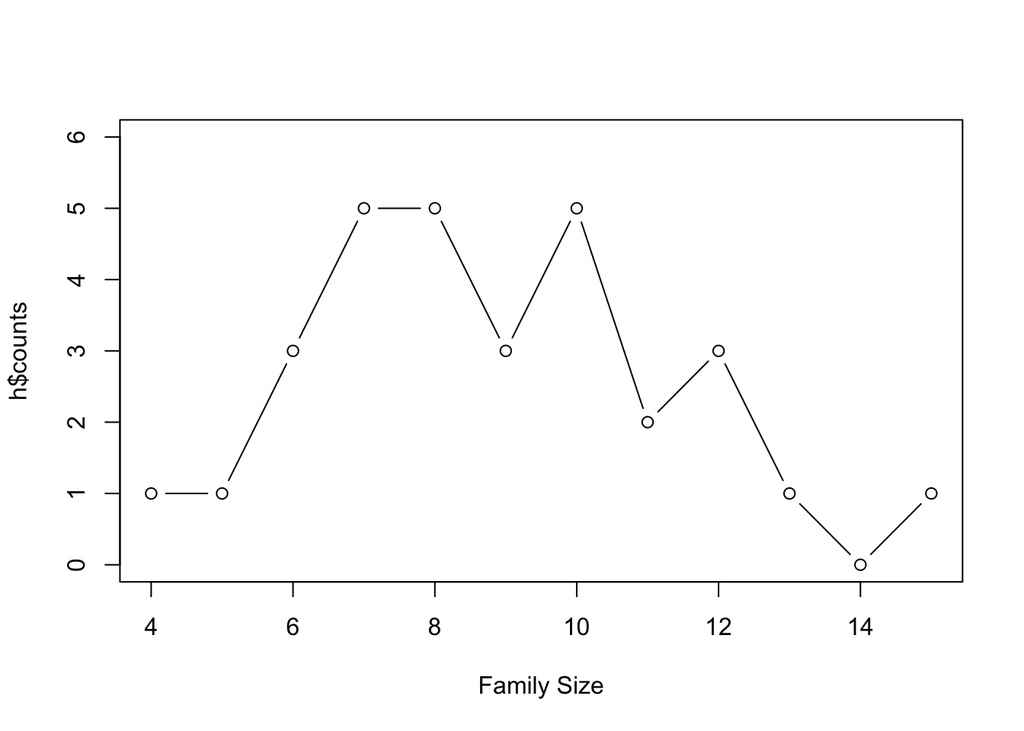

```r
freqpoly(size,
         breaks = 3.5:15.5,
         ylim = c(0, 6), xlab = "Family Size")
```

### #3

3. 9
4. 6

## Section 2.3

### #1

The right = FALSE makes all the intervals left inclusive, i.e., $[90, 100), [100, 110), [110, 120), [120, 130), [130, 140), [140, 150)$, so that 100 belongs to the second bin instead of the first bin.

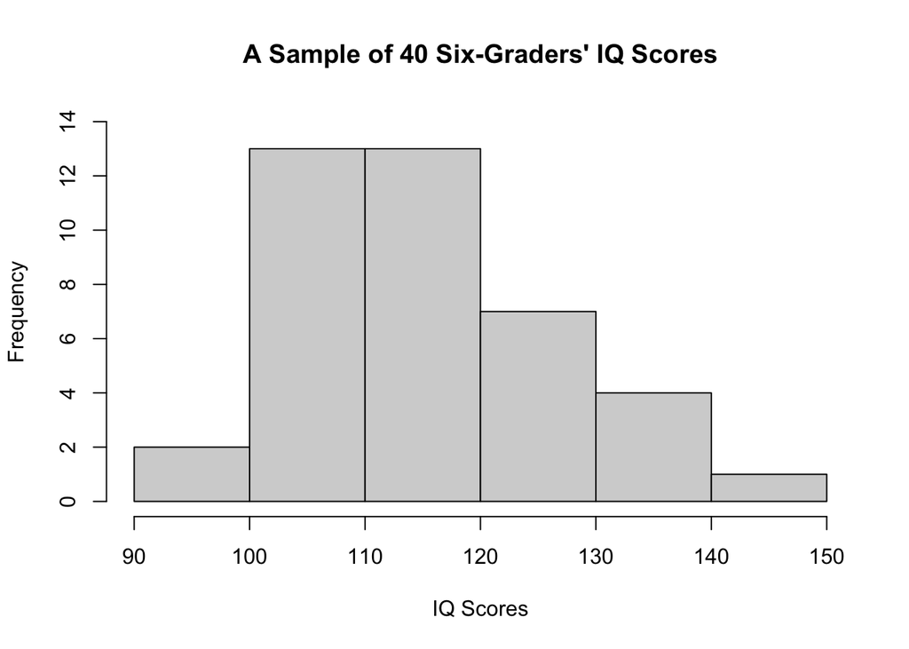

```r
iq <- c(114, 122, 103, 118, 99, 105, 134, 125, 117, 106, 109, 104, 111, 127,
133, 111, 117, 103, 120, 98, 100, 130, 141, 119, 128, 106, 109, 115,
113, 121, 100, 130, 125, 117, 119, 113, 104, 108, 110, 102)
hist(iq, breaks = c(90, 100, 110, 120, 130, 140, 150),
     ylim = c(0, 14), xlab = "IQ Scores", right = FALSE,
     main = "A Sample of 40 Six-Graders' IQ Scores")
```

### #3

Don’t forget to add meaningful x-axis labels and titles.

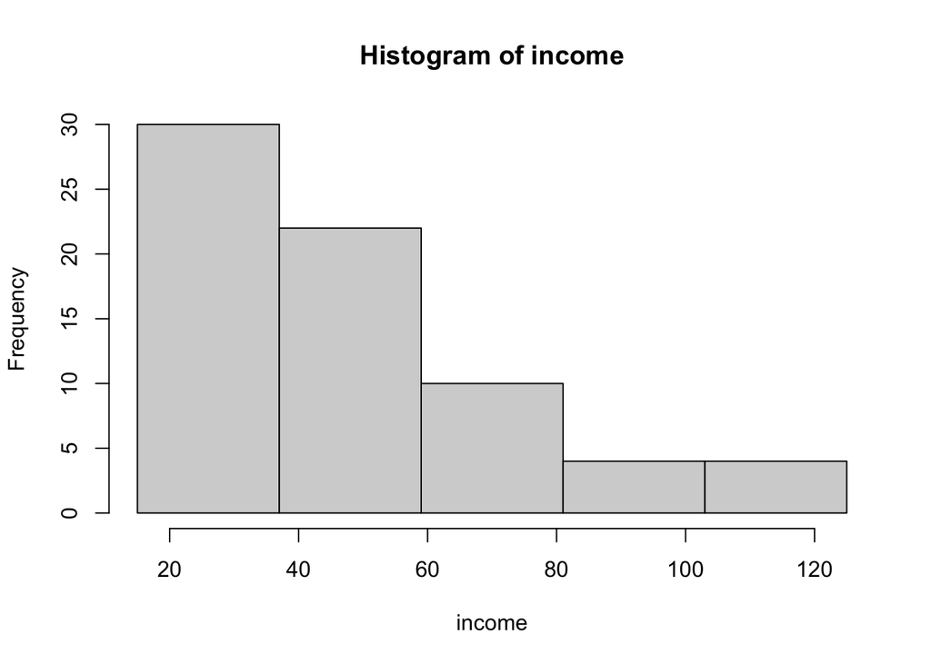

```r
income <- c(47, 55, 18, 24, 27, 41, 50, 38, 33, 29, 15, 77, 64, 22, 19, 35, 39, 41,
67, 55, 121, 77, 80, 34, 41, 48, 60, 30, 22, 28, 84, 55, 26, 105, 62,
30, 17, 23, 31, 28, 56, 64, 88, 104, 115, 39, 25, 18, 21, 30, 57, 40,
38, 29, 19, 46, 40, 49, 72, 70, 37, 39, 18, 22, 29, 52, 94, 86, 23, 36)
hist(income, breaks = c(15, 37, 59, 81, 103, 125), right = FALSE)
```

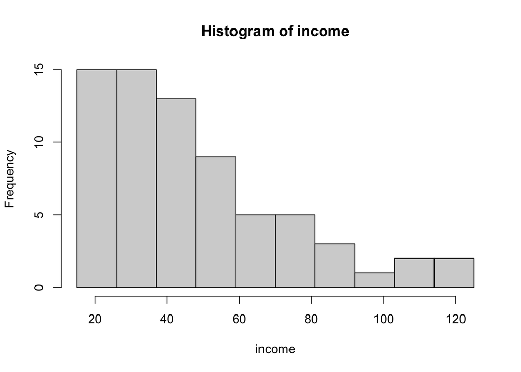

```r
hist(income, breaks = c(15, 26, 37, 48, 59, 70, 81, 92, 103, 114, 125), right = FALSE)
```

# Homework 3

## Section 3.2

### #11

The mean is 6.5 fires.

### #17

$\dfrac{30\times 73600 + 20 \times 92400}{50}$. This is called a weighted average.

## Section 3.3

### #11

The histograms on the book are bad examples. There should be **no gap** between the bins.

- If you think the bins are based on the following intervals [15, 16), [16, 17), [17, 18), [18, 19), [19, 20), [20, 21), [21, 22), [22, 23), [23, 24), [24, 25], then the book answers make sense.
  1. Use the largest possible value on each interval, i.e., 16, 17, …, 25.
     $$\dfrac{16\times 1 + 17\times 3 + 18 \times 3 + 19 \times 4 + 20 \times 6 + 21 \times 4 + 22 \times 3 + 23 \times 5 + 24 \times 2 + 25\times 3}{34}$$
  2. Use the largest possible value on each interval, i.e., 16, 17, …, 25.
  3. Use the smallest possible value on each interval, i.e., 15, 16, …, 24.
  4. Use the smallest possible value on each interval, i.e., 15, 16, …, 24.
- Otherwise, if you believe the bins are based on the following intervals [14.5, 15.5), [15.5, 16.5), [16.5, 17.5), [17.5, 18.5), [18.5, 19.5), [19.5, 20.5), [20.5, 21.5), [21.5, 22.5), [22.5, 23.5), [23.5, 24.5], then your answers will be
1. 20.24
2. 20
3. 19.24
4. 19

## Section 3.3.1

### #9

- If you use `quantile(..., 0.75, type = 2)`, you will find $Q3=92$ as stated in the book answers.
- If you use `fivenum(...)`, you will find $Q3$ to be $91.5$. Either one is fine.

# Homework 4

## Section 4.3

### #13

0.31 or 31%

# Homework 5

## Section 4.5

### #3

Please make the following corrections to the question.

1. Is a woman given that he or she earns over $50,000.
2. Earns over $50,000 given that this worker is a woman.

### #11

12/2028 = 0.0059172

The event that two cards are of different suits has $52\times 39 = 2028$ outcomes. (The first card can be any of the 52 cards. But once the first card is drawn, the second card is limited to one of the oher three suits, i.e., one of 39 cards.)

Of those 2028 outcomes, 12 are corresponding to both cards are aces. (The first card can be any of the four aces, then the second card can be any of the rest three aces.)

### #41(a)

- Let $PHX$ be the event that it rains on the Phoenix trip.
- Let $LAX$ be the event that it rains on the Los Angeles trip.
- Let $MOB$ be the event that it rains on the Mobile trip. ($MOB^c$ means no rain in the trip.)

The probability we are about to find out is

$$P(PHX \cap LAX\cap MOB ) = P(PHX) \cdot P(LAX) \cdot P(MOB) = \frac{4}{31}\cdot\frac{3}{30}\cdot \frac{16}{31}=0.0066597,\\$$

where $P(MOB)=16/31$ because the trip is in July (which has 31 days) and the trip day could be any of the 16 rainy days of July.

# Homework 6

## Section 4.7

### #1

175760000

### #5

FYI: In 1995, the North American Numbering Plan Administrator (NANP) removed the requirement that the middle digit of an area code had to be either 0 or 1. Here is [a map of all the area codes in 1947](http://www.lincmad.com/map1947.html). (What was Georgia’s area code in 1947?) So, before 1995,

- There are 144 possible area codes.
- There are 18 starting with a 4.

### #11

1. 5
2. 0.6

### #13

Hint: This is very similar to the lottery example we covered in class. Starting with dividing the chips into two piles: the 86 good ones and the 14 defective ones.

1. 0.2045541
2. 0.3719165
3. 0.4235294

### #17

Hint: Another similar problem of the lottery example we covered in class. The questions can be divided into two categories: the 7 questions the student knows how to solve and the 3 questions that the student doesn’t know how to solve.

1. 0.0833333
2. 0.5

## Section 5.3

### #29

Let $X$ be the number of cakes sold. If the bakery bakes 2 cakes daily, then the probability distribution of $X$ is

| $X$ | $P(X)$ |
| --- | --- |
| 0 | 0.15 |
| 1 | 0.25 |
| 2 | 0.6 |

- If no cake is sold, the profit is $-4\times 2 = -8$ dollars. (Probability 0.15)
- If one cake is sold, the profit is $20 - 4\times 2 = 12$ dollars. (Probability 0.25)
- If both cakes are sold, the profit is $20\times 2 - 4 \times 2=32$ dollars. (Probability 0.6)

Therefore, if two cakes are baked daily, the expected profit is
$$-8(0.15) + 12(0.25) + 32(0.6)=\$21.$$

Repeat the same process (reconstruct the probability distribution table) to find the expected profit for baking 3 and 4 cakes, separately. (Answer: $23 if 3 cakes are baked daily and $22 if 4 cakes are baked daily).

# Homework 8

## Section 7.5

### #3

$E[\hat p]=p=0.1$, and $SD(\hat p) = \sqrt{\dfrac{p(1-p)}{n}}=\sqrt{\dfrac{0.1(1-0.1)}{50}}$. By [continuous correction](https://albums.yuanting.lu/sta126/10-samplingDistribution.html#Continuous_Correction),

1. The approximate probability of getting no defective batteries is

   ```r
   pnorm(0.5 / 50, 0.1, sqrt(0.1 * 0.9 / 50)) - pnorm(- 0.5 / 50, 0.1, sqrt(0.1 * 0.9 / 50))
   ```

   ```
   ## [1] 0.01218648
   ```

2. The approximate probability of getting more than 15% defective batteries (i.e., 8 or more) in a sample of 50 is

   ```r
   1 - pnorm(7.5 / 50, 0.1, sqrt(0.1 * 0.9 / 50))
   ```

   ```
   ## [1] 0.1192964
   ```

3. The approximate probability of getting between 8% (i.e., 4) and 12% (i.e., 6) defective batteries in a sample of 50 is

   ```r
   pnorm(6.5 / 50, 0.1, sqrt(0.1 * 0.9 / 50)) - pnorm(3.5 / 50, 0.1, sqrt(0.1 * 0.9 / 50))
   ```

   ```
   ## [1] 0.5204999
   ```

### #5

$E[\hat p]=p=0.092$, and $SD(\hat p) = \sqrt{\dfrac{p(1-p)}{n}}=\sqrt{\dfrac{0.092(1-0.092)}{400}}$. By [continuous correction](https://albums.yuanting.lu/sta126/10-samplingDistribution.html#Continuous_Correction),

1. The approximate probability that 40 or fewer German workers were unemployed is

   ```r
   pnorm(40.5 / 400, 0.092, sqrt(0.092 * (1 - 0.092) / 400))
   ```

   ```
   ## [1] 0.73894
   ```

2. The approximate probability that more than 50 German workers were unemployed is

   ```r
   1 - pnorm(50.5 / 400, 0.092, sqrt(0.092 * (1 - 0.092) / 400))
   ```

   ```
   ## [1] 0.008893335
   ```

### #9

$E[\hat p]=p=0.4$, and $SD(\hat p) = \sqrt{\dfrac{p(1-p)}{n}}=\sqrt{\dfrac{0.4(1-0.4)}{350}}$. By [continuous correction](https://albums.yuanting.lu/sta126/10-samplingDistribution.html#Continuous_Correction),

1. The approximate probability that more than 160 accepted students attending is

   ```r
   1 - pnorm(160.5 / 350, 0.4, sqrt(0.4 * (1 - 0.4) / 350))
   ```

   ```
   ## [1] 0.01265189
   ```

2. The approximate probability that fewer than 150 accepted students attending is

   ```r
   pnorm(149.5 / 350, 0.4, sqrt(0.4 * (1 - 0.4) / 350))
   ```

   ```
   ## [1] 0.8500237
   ```

### #17

$E[\hat p]=p= 1 - 0.54 = 0.46$, and $SD(\hat p) = \sqrt{\dfrac{p(1-p)}{n}}=\sqrt{\dfrac{0.46(1-0.46)}{500}}$. By [continuous correction](https://albums.yuanting.lu/sta126/10-samplingDistribution.html#Continuous_Correction),

1. The approximate probability that fewer than 250 graduate in four years is

   ```r
   pnorm(249.5 / 500, 0.46, sqrt(0.46 * (1 - 0.46) / 500))
   ```

   ```
   ## [1] 0.9599185
   ```

The approximate probability that more than 175 but fewer than 225 students graduate within 4 years is 0.311.

### #19

By [continuous correction](https://albums.yuanting.lu/sta126/10-samplingDistribution.html#Continuous_Correction),

1. The approximate probability that at least 25 are overweight by 30 percent or more is 0.9973.
2. The approximate probability that fewer than 50 sleep 6 hours or less nightly is 0.0193.

# Homework 9

## Section 8.2

### #3

```r
book_costs <- c(422, 146, 368, 52, 212, 454, 366, 711, 227, 680)
mean(book_costs)
```

```
## [1] 363.8
```

# Homework 10

## Section 9.5

### #1

Let $p$ be the true proportion of patients who get effective treatment by using the new drug.

- $H_0: p = 0.72$
- $H_1: p>0.72$
- P-value:

```r
1 - pbinom(41, 50, 0.72)
```

```
## [1] 0.03645886
```

```r
1 - pnorm(41.5/50, 0.72, sqrt(0.72 * 0.28 / 50))
```

```
## [1] 0.04160677
```

Conclusion: Based on a 0.05 significance level, the p-value is small. We reject the null hypothesis. There is sufficient evidence to show that the new drug is more effective than the old one.

### #3

- P-value = 0.262 (Binomial).
- P-value = 0.256 (Normal approximation with continuous correction).

### #5

- (b). P-value = 0.136
- (c). P-value = 0.052
- (d). P-value = 0.004

### #9

- P-value = 0.292 (Binomial).
- P-value = 0.314 (Normal approximation with continuous correction).

### #11

- P-value = 0.17

### #15

- P-value = 0 (round to three decimal places).

# Homework 11

## Section 8.5

### #11

From question 10, MOE is 2045.32. So to maintain the MOE while increase the confidence level to 99%, we need

```r
(qnorm(0.995) * 3300 / 2045.32) ^ 2
```

```
## [1] 17.27188
```

At least 18 tires.

# Homework 12

## Section 9.3

### #1

Let $\mu$ be the actual distance from Earth to the asteroid Phyla.

- $H_0: \mu = 14.4$
- $H_1: \mu \ne 14.4$
- The sample mean is $\bar{x}=14.717$. Thus the test statistic is $\dfrac{14.717 - 14.4}{0.5/\sqrt{6}}=1.55$.
- P-value $= 2\times P(\bar{x} > 14.717) = 0.12$

```r
2 * (1 - pnorm(1.55))
```

```
## [1] 0.1211415
```

Based on a 005 significance level, the p-value is not small. Therefore, we do not reject the null hypothesis, which means there is no sufficient evidence to show that the actual distance from Earth to the asteroid Phyla is different from 14.4 light years.

### #5

P-value = 0.0455

### #7

P-value = 0

### #13

P-value = 0.281

## Section 9.3.1

### #1

P-value = 0.091

### #9

P-value = 0

## Section 9.4

### #1

P-value = 0.260

### #7

P-value = 0.00076

### #13

P-value = 0.0694

### #15

P-value = 0.0068

# Homework 13

## Section 10.4

### #1

- Let $\mu_1$ be the true systolic blood pressure for all smokers.
- Let $\mu_2$ be the true systolic blood pressure for all nonsmokers.
- $H_0: \mu_1 = \mu_2$
- $H_1: \mu_1 \ne \mu_2$

```r
s <- c(124, 134, 136, 125, 133, 127, 135, 131, 133, 125, 118)
ns <- c(130, 122, 128, 129, 118, 122, 116, 127, 135, 120, 122, 120, 115, 123)
t.test(s, ns, alternative = "two.sided")
```

```
##
##  Welch Two Sample t-test
##
## data:  s and ns
## t = 2.5239, df = 21.636, p-value = 0.01947
## alternative hypothesis: true difference in means is not equal to 0
## 95 percent confidence interval:
##   1.033961 10.615390
## sample estimates:
## mean of x mean of y
##  129.1818  123.3571
```

- Based on a significance level of 0.01, the p-value is not small. We do not reject the null hypothesis. There is no sufficient evidence to show that the mean systolic blood pressure levels are different between smokers and nonsmokers.
- Based on a significance level of 0.05, the p-value is small. We reject the null hypothesis. There is sufficient evidence to show that the mean systolic blood pressure levels are different between smokers and nonsmokers.

### #3

```r
generic <- c(14.2, 14.7, 13.9, 15.3, 14.8, 13.6, 14.6, 14.9, 14.2)
name <- c(14.3, 14.9, 14.4, 13.8, 15.0, 15.1, 14.4, 14.7, 14.9)
t.test(generic, name, alternative = "greater")
t.test(name, generic, alternative = "less")
```

[output not shown]

## Section 10.5

### #1

```r
before <- c(73, 67, 68, 60, 76, 80, 73, 77, 66, 58, 82, 78)
after <- c(77, 69, 73, 70, 74, 88, 76, 82, 69, 61, 84, 80)
t.test(before, after, alternative = "two.sided", paired = TRUE)
```

```
##
##  Paired t-test
##
## data:  before and after
## t = -4.2197, df = 11, p-value = 0.001437
## alternative hypothesis: true difference in means is not equal to 0
## 95 percent confidence interval:
##  -5.705997 -1.794003
## sample estimates:
## mean of the differences
##                   -3.75
```

### #5

```r
x1 <- c(23, 30, 25, 18, 19, 25, 28, 22, 31, 29, 24, 28, 31, 27)
x2 <- c(18, 25, 28, 22, 14, 34, 36, 15, 23, 27, 26, 19, 30, 28)
t.test(x1, x2, alternative = "two.sided", paired = TRUE)
```

```
##
##  Paired t-test
##
## data:  x1 and x2
## t = 0.69469, df = 13, p-value = 0.4995
## alternative hypothesis: true difference in means is not equal to 0
## 95 percent confidence interval:
##  -2.260535  4.403393
## sample estimates:
## mean of the differences
##                1.071429
```

## Section 10.6

### #1

```r
prop.test(c(20, 12), c(100, 100), alternative = "two.sided")
```

```
##
##  2-sample test for equality of proportions with continuity correction
##
## data:  c(20, 12) out of c(100, 100)
## X-squared = 1.8229, df = 1, p-value = 0.177
## alternative hypothesis: two.sided
## 95 percent confidence interval:
##  -0.03100948  0.19100948
## sample estimates:
## prop 1 prop 2
##   0.20   0.12
```

### #11

```r
prop.test(c(78, 90), c(82, 120), alternative = "greater")
```

```
##
##  2-sample test for equality of proportions with continuity correction
##
## data:  c(78, 90) out of c(82, 120)
## X-squared = 12.689, df = 1, p-value = 0.0001839
## alternative hypothesis: greater
## 95 percent confidence interval:
##  0.1150713 1.0000000
## sample estimates:
##    prop 1    prop 2
## 0.9512195 0.7500000
```

## Section 12.3

### #3(c)

To find the line equation:

```r
distance <- c(5.2, 4.4, 3, 1.2, 7.5, 9.4)
damage <- c(36.2, 28.8, 22.6, 8.8, 41.5, 25.4)
lm(damage ~ distance)
```

```
##
## Call:
## lm(formula = damage ~ distance)
##
## Coefficients:
## (Intercept)     distance
##      14.787        2.429
```

In case you would like to know how to add the line to the scatter plot, here it is. (Google “pch in r” to see the list of available markers.)

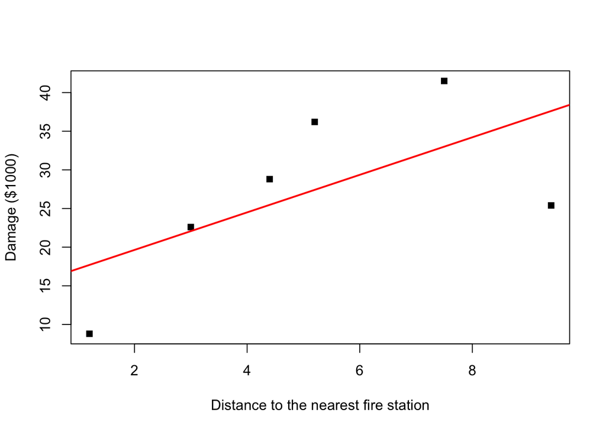

```r
plot(damage ~ distance, pch = 15,
     xlab = 'Distance to the nearest fire station',
     ylab = "Damage ($1000)")
abline(lm(damage ~ distance), col = 'red', lwd = 2)
```